# Pacific Ocean Perch

*Sebastes alutus*

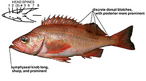

**Body color:** Light red, including fins; dark olivaceous areas on back under soft dorsal fin and on caudal peduncle.

**Peritoneum color:** dark **Shape between eyes:** convex to flat

**Counts:** D:XIII-XIV,13-17, Ar:6-9, P1:15-19, GR:30-39, LLp:44-55, LLs:43-55, V:27

**Occurence:** Bering Sea - Baja California

**Depth:** 100-825 meters **Size:** 55 cm **Species code:** 30060

**Similar species:**

- *Yellowmouth rockfish* - symphyseal knob weaker, rounded; yellow, red, and black blotches inside mouth; specimens <40 cm w/ discrete opercular blotch, diffuse dorsal blotches; 57-67 scales below lateral line (43-55 in POP)
- *Sharpchin rockfish* - dorsal blotches large w/ at least one extending across lateral line; forked bar radiates from eye; head spines strong and count differs; anal spine 2 longer than 3; dorsal rays typically 14 (typically 15 in POP); anal rays typically 7 (typically 8 in POP); pectoral rays typically 17 (typically 18 in POP)
- *Redstripe rockfish* - lateral line light, contrasted by dark mottling above and below; head spine count typically differs
- *Northern rockfish* - dorsal spines typically 14; dark bars radiate posteriorly from eye; pectoral fin w/ oblique pink slash on ventral portion; head spine count differs
- *Chilipepper rockfish* - dorsal blotches absent; lateral line red or pink; belly whitish; peritoneum light; head spine count differs

Back to Group

**Corrections:** If you see mistakes or want to suggest changes, please create an [issue](https://github.com/zoyafuso-NOAA/RACE_Survey_App/issues) on the source repository or

*reach out to Liz Dawson (Liz.Dawson AT noaa.gov).*